# Logistic Regression Tutorial

We use **logistic regression** to predict the probability of a *categorical* dependent variable (with 2 values, usually 0 and 1), with some other *continuous* independent variable(s). That is, the logistic regression model predicts P(Y=1) as a function of X.

## Look at the data

To get started, let’s load in a dataset (info about the variables can be found [here](http://stanford.edu/class/psych252/data/)):

```r
d0 = read.csv("http://www.stanford.edu/class/psych252/data/hw2data.csv")
summary(d0)
```

```
##       Type         Pasthapp      Responsible   Futurehapp
##  Min.   :1.00   Min.   : 0.00   Min.   : 0   Min.   : 0.00
##  1st Qu.:1.00   1st Qu.: 2.00   1st Qu.: 5   1st Qu.: 2.00
##  Median :2.00   Median : 4.00   Median :14   Median : 5.00
##  Mean   :1.94   Mean   : 4.78   Mean   :11   Mean   : 4.25
##  3rd Qu.:3.00   3rd Qu.: 7.00   3rd Qu.:16   3rd Qu.: 5.00
##  Max.   :3.00   Max.   :15.00   Max.   :20   Max.   :15.00
##       FTP          complain
##  Min.   : 3.0   Min.   :0.000
##  1st Qu.:10.0   1st Qu.:0.000
##  Median :13.0   Median :0.000
##  Mean   :12.4   Mean   :0.476
##  3rd Qu.:15.0   3rd Qu.:1.000
##  Max.   :19.0   Max.   :1.000
```

```r
# factor d0$Type (i.e., memory groups), since it is categorical
d0$Type = factor(d0$Type)
head(d0)
```

```
##   Type Pasthapp Responsible Futurehapp FTP complain
## 1    2        2          10          5  12        1
## 2    3       10           5          5  18        1
## 3    1        2          18          3   9        0
## 4    3        5          15          0  15        1
## 5    1        7          17          7  17        1
## 6    1        0          20          5  15        0
```

Now, we might be interested in whether or not a participant’s **self-reported feelings of responsibility** of missing a plane or a train (`d0$Responsible`) influences whether or not they **considered complaining** (`d0$complain`).

First, let’s take a look at the data in a few different ways:

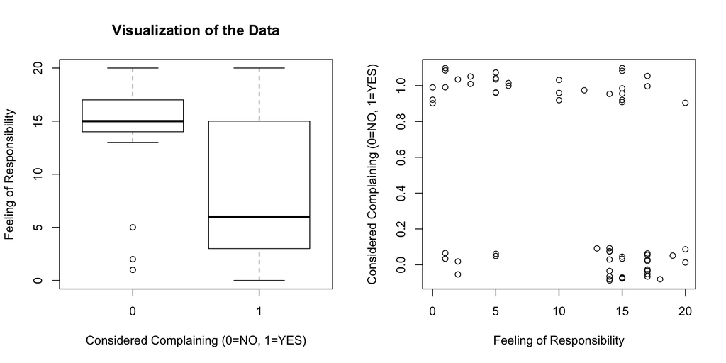

```r
par(mfrow=c(1,2))
plot(factor(d0$complain), d0$Responsible, xlab=("Considered Complaining (0=NO, 1=YES)"), ylab="Feeling of Responsibility")
title(main="Visualization of the Data")

plot(jitter(d0$complain, factor=0.5)~d0$Responsible, ylab="Considered Complaining (0=NO, 1=YES)", xlab="Feeling of Responsibility")
```

Based on these plots, it looks like participants who felt more responsible about missing a plane or a train considered complaining less than participants who felt less responsible for missing a plane/train. Let’s test this hypothesis formally.

## Hypothesis Testing

Here we will examine how a participant’s feeling of *responsibility* influences their tendency to *complain*. Since `complain` is a binary coded variable (i.e., with values of 0 or 1), `complain` is categorical rather than continuous. Thus, we are faced with a **classification** problem, rather than a **linear regression** problem. That is, given a person with some value of `Responsible`, we want to predict whether or not that person is likely to complain; in other words, we want to *classify* that person as “complainer”" (`complain` = 1), or a non-complainer (`complain` = 0). **Logistic regression** can be used to solve a classification problem like this.

### What if we were to model the data with linear regression?

Here, we’ve plotted the data, and the linear regression line-of-best-fit:

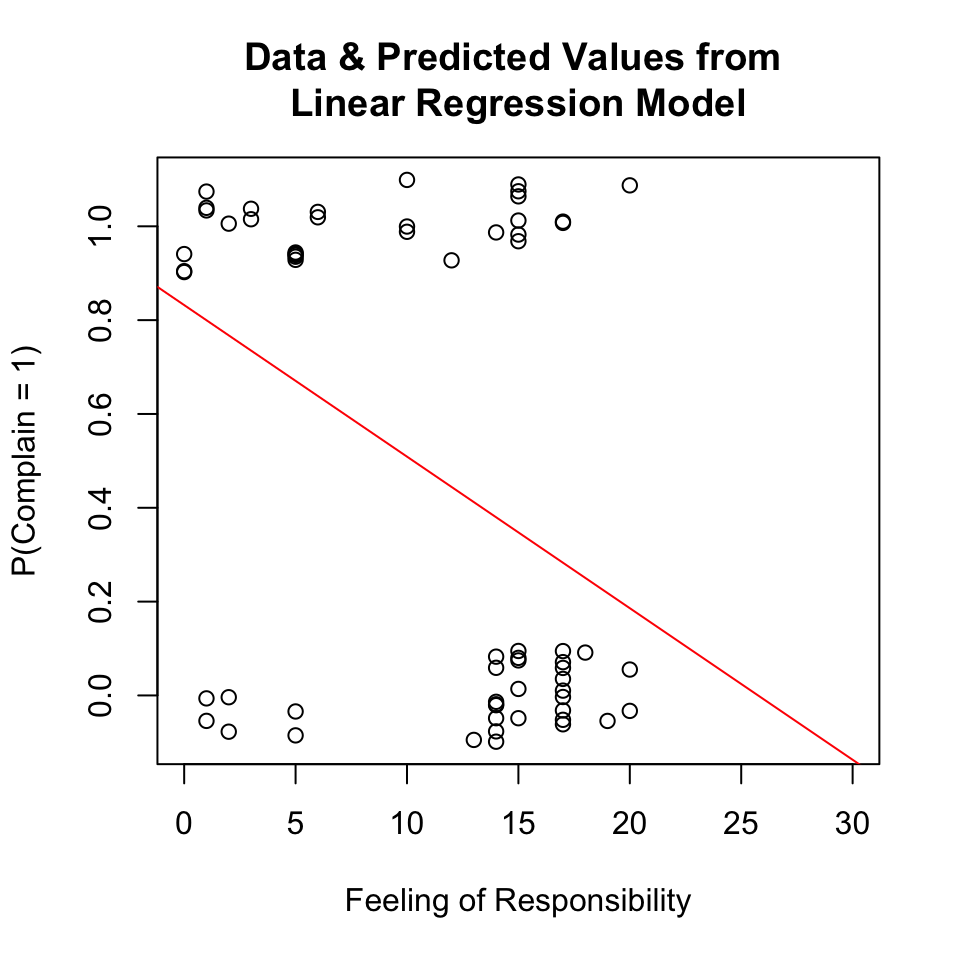

```r
plot(jitter(d0$complain, factor=0.5)~d0$Responsible, ylab="P(Complain = 1)", xlab="Feeling of Responsibility", xlim=c(0,30))

abline(lm(d0$complain~d0$Responsible), col='red')
title(main="Data & Predicted Values from \nLinear Regression Model")
```

**A few things to note:**

1. The line-of-best-fit tells us the **predicted probability** of complaining (i.e., P(`complain` = 1)) for each level of `Responsible`. For example, someone with a responsible level of “10” would have a 50% probability of complaining; someone with a responsible level of “5” would have a 70% probability of complaining.
2. For greater levels of `Responsible`, the model from linear regression predicts that the probability of complaining would be *less than* 0. This is impossible!

### Sigmoid (logistic) function

Since a straight line won’t fit our data well, we instead will use an S-shaped, **sigmoid** function. This function ensures that our output values will fall between 0 and 1, for any value of `x`. Further, please note that this function outputs the *probability* that `y` = 1.

The sigmoid (or “logistic”) function is given by the equation:  
_______ $P(y=1) = \frac{e^{(b + mx)}}{1+e^{(b + mx)}}$ _______

That is, the probability of a person complaining (`complain` = 1) is a function of `x`, *e* (the base of the natural logarithm, $\approx$ 2.718), and the coefficients from the generalized linear model (`b` = intercept, `m` = coefficient for `Responsible`).

Here’s an example of the sigmoid function plotted:

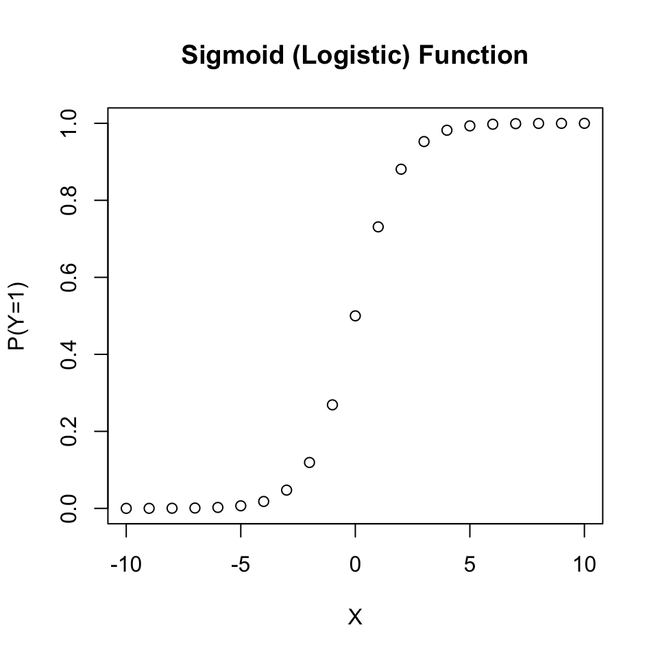

```r
x <- c(-10:10)
b = 0 # intercept
m = 1 # slope
y <- exp((b + m*x)) / (1 + exp((b + m*x)))
plot(x, y, xlab="X", ylab="P(Y=1)")
title(main="Sigmoid (Logistic) Function")
```

If you want to explore how varying the slope and intercept change the shape of the sigmoid function, try changing the coefficients in the .Rmd file, or check out the app [here](http://spark.rstudio.com/supsych/logistic_regression/)).

Before, we mentioned that the sigmoid (logistic) function outputs the *probability* that $Y$ = 1. This is is because the *logistic* regression is essentially *linear* regression on the **logit transform** of our original $Y$. Solving our sigmoid function above for `b + mx` = $\hat{y}$, we find that $\hat{y}$ is the **logit**, sometimes referred to as **log odds**.

$logit(p) = \hat{y} = b + mx= log(\frac{p}{1-p}) = log(\frac{P(Y=1)}{P(Y=0)})$

### Running a general linear model w/ glm()

To estimate the intercept and slope coefficients, we can run a **generalized linear model** using the R function `glm()`.

```r
rs1 = glm(complain ~ Responsible, data = d0, family = binomial, na.action = na.omit)
summary(rs1)
```

```
##
## Call:
## glm(formula = complain ~ Responsible, family = binomial, data = d0,
##     na.action = na.omit)
##
## Deviance Residuals:
##    Min      1Q  Median      3Q     Max
## -1.775  -0.915  -0.673   0.898   1.786
##
## Coefficients:
##             Estimate Std. Error z value Pr(>|z|)
## (Intercept)   1.4866     0.5917    2.51    0.012 *
## Responsible  -0.1428     0.0462   -3.09    0.002 **
## ---
## Signif. codes:  0 '***' 0.001 '**' 0.01 '*' 0.05 '.' 0.1 ' ' 1
##
## (Dispersion parameter for binomial family taken to be 1)
##
##     Null deviance: 87.194  on 62  degrees of freedom
## Residual deviance: 76.013  on 61  degrees of freedom
## AIC: 80.01
##
## Number of Fisher Scoring iterations: 4
```

```r
# show coeffecients
rs1$coefficients
```

```
## (Intercept) Responsible
##      1.4866     -0.1428
```

Now, let’s take the coefficients from the model, and put them into our sigmoid function to **generate predicted values**:

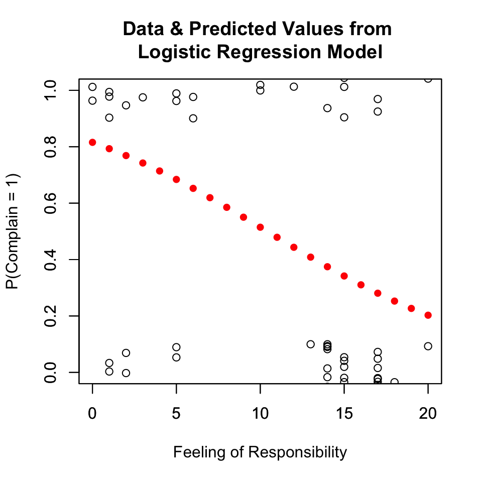

```r
# plot the data
plot(jitter(d0$complain, factor=0.5)~d0$Responsible, ylab="P(Complain = 1)", xlab="Feeling of Responsibility", ylim=c(0,1), xlim=c(0,20))

# plot the predicted values using the sigmoid function
x <- c(0:20)
b = rs1$coefficients[1] # intercept
m = rs1$coefficients[2] # slope
y <- exp((b + m*x)) / (1 + exp((b + m*x)))

par(new=TRUE) # don't erase what's already on the plot!
plot(x, y, xlab="", ylab="", pch = 16, ylim=c(0,1), xlim=c(0,20), col='red')
title(main="Data & Predicted Values from \nLogistic Regression Model")
```

Since the slope ($m$ = -0.1428; i.e., the coefficient for `Responsible`) is negative, the function is flipped from the S-shaped sigmoid shown above. Further, since the slope is small, the drop-off in the function is more gradual.

### Interpreting the output from glm()

Before we noted that the logistic/sigmoid function outputs the **probability** that $Y$ = 1 for a given value of $x$. In this example, P(`complain` = 1) – the probability that someone considered complaining – if they had a self-reported feeling of responsibility = 5 would be equal to: $P(Y=1) = \frac{e^{(1.4866 + -0.1428 * 5)}}{1+e^{(1.4866 + -0.1428 * 5)}}$

Which would equal:

```r
x = 5
b = rs1$coefficients[1] # intercept
m = rs1$coefficients[2] # slope
y <- exp((b + m*x)) / (1 + exp((b + m*x)))

as.numeric(y)
```

```
## [1] 0.6841
```

Thus, based on our logistic regression model, the probability that a person with a self-reported responsibility = 5 would have a 68.4087% probability of complaining.

### Log odds

We can also extract the **log odds** from our `glm()` output. In our example, log odds essentially captures the ratio of (being a “complainer”):(not being a “complainer”). In logistic regression, the dependent variable ($\hat{y}$, or $b + mx$) is referred to as the **logit**, which is the natural log of the odds.

As noted above, by rearranging the logistic function, we get the equation for the logit: $\hat{y} = b + mx= log(\frac{p}{1-p})$

Since the predicted variable here is log odds, the coefficient of “Responsible” can be interpreted as **“for every one unit increase in self-reported responsibility, the odds of complaining change by $e^{(-0.1428)}$ = 0.8669 times.”** Note that when the *log odds* are negative, the *odds* will be < 1. This means that here we would expect to see a 13.3062% *decrease* in the odds of complaining.

## Some more ways to vizualize logistic regression data/results

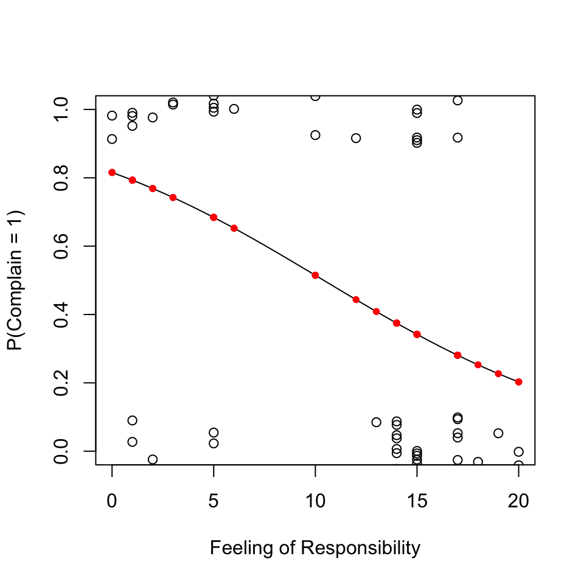

```r
# plot the data
plot(jitter(d0$complain, factor=0.5)~d0$Responsible, ylab="P(Complain = 1)", xlab="Feeling of Responsibility", ylim=c(0,1), xlim=c(0,20))

# draw a curve based on prediction from logistic regression model
Responsible = d0$Responsible
curve(predict(rs1, data.frame(Responsible = x), type = "resp"), add = TRUE)

points(d0$Responsible,fitted(rs1),pch=20, col='red')
```

```r
install.packages("popbio", repos="http://ftp.ussg.iu.edu/CRAN/"); library(popbio)
```

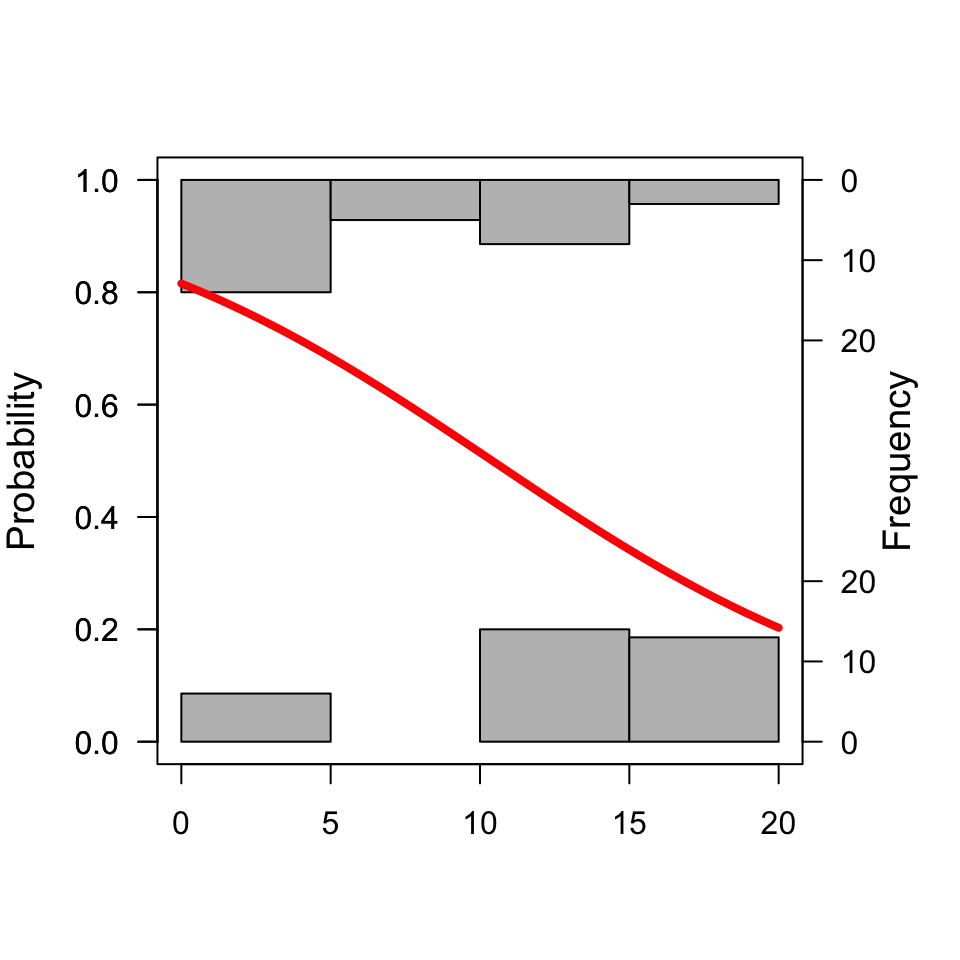

```r
logi.hist.plot(d0$Responsible,d0$complain,boxp=FALSE,type="hist",col="gray")
```